# Atividade - Modelagem

Rita de Cássia

2023-11-20

## Obtendo os dados

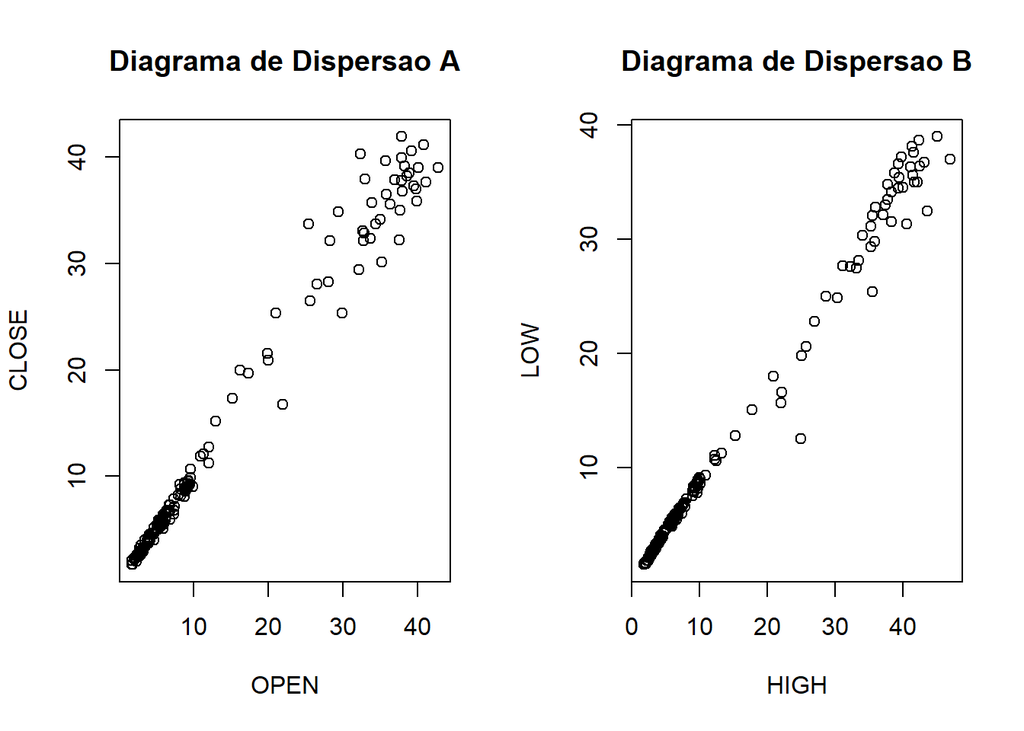

```r
base <- read.csv("C:/Users/ritad/Desktop/Faculdade/Aprendendo_Calculos/Aulas de R/Exercicios/base-r-wege-full.csv")

par(mfrow = c(1, 2))
plot(base$Open, base$Close, main = "Diagrama de Dispersao A", xlab = "OPEN", ylab = "CLOSE")
plot(base$High, base$Low, main = "Diagrama de Dispersao B", xlab = "HIGH", ylab = "LOW")
```

### Aproximando uma reta

```r
#Criando os modelos
modeloWegeO <- lm(base$Open ~ base$Close)
summary(modeloWegeO)
```

```
##
## Call:
## lm(formula = base$Open ~ base$Close)
##
## Residuals:
##     Min      1Q  Median      3Q     Max
## -7.8459 -0.2938 -0.0235  0.2800  5.6908
##
## Coefficients:
##              Estimate Std. Error t value Pr(>|t|)
## (Intercept) -0.002186   0.175520  -0.012     0.99
## base$Close   0.987321   0.009781 100.947   <2e-16 ***
## ---
## Signif. codes:  0 '***' 0.001 '**' 0.01 '*' 0.05 '.' 0.1 ' ' 1
##
## Residual standard error: 1.666 on 175 degrees of freedom
## Multiple R-squared:  0.9831, Adjusted R-squared:  0.983
## F-statistic: 1.019e+04 on 1 and 175 DF,  p-value: < 2.2e-16
```

```r
#Criando os modelos
modeloWegeH <- lm(base$High ~ base$Low)
summary(modeloWegeH)
```

```
##
## Call:
## lm(formula = base$High ~ base$Low)
##
## Residuals:
##     Min      1Q  Median      3Q     Max
## -3.4042 -0.3443 -0.1535  0.1103 10.3444
##
## Coefficients:
##              Estimate Std. Error t value Pr(>|t|)
## (Intercept) -0.001659   0.147283  -0.011    0.991
## base$Low     1.159481   0.008875 130.649   <2e-16 ***
## ---
## Signif. codes:  0 '***' 0.001 '**' 0.01 '*' 0.05 '.' 0.1 ' ' 1
##
## Residual standard error: 1.399 on 175 degrees of freedom
## Multiple R-squared:  0.9899, Adjusted R-squared:  0.9898
## F-statistic: 1.707e+04 on 1 and 175 DF,  p-value: < 2.2e-16
```

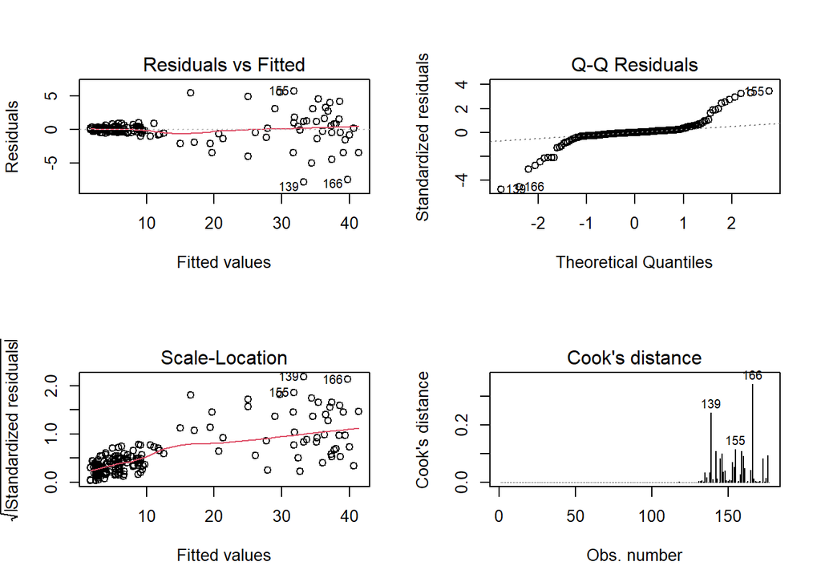

```r
par(mfrow=c(2,2))
plot(modeloWegeO, which = 1:4)
```

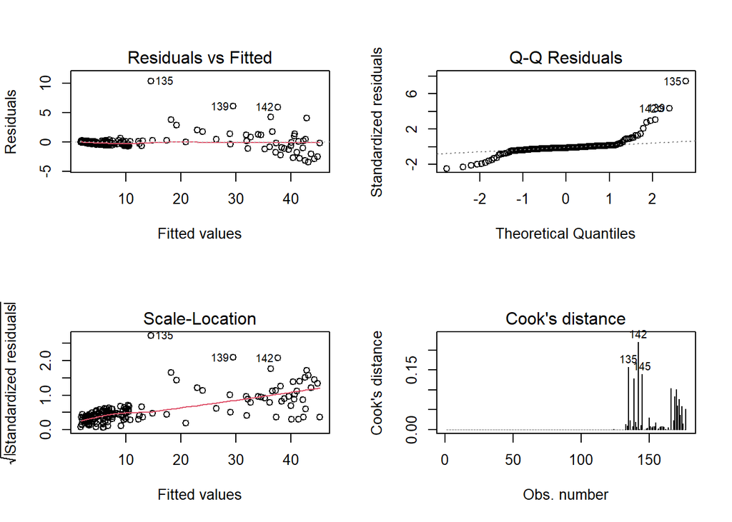

```r
plot(modeloWegeH, which = 1:4)
```

#### Breve Análise:

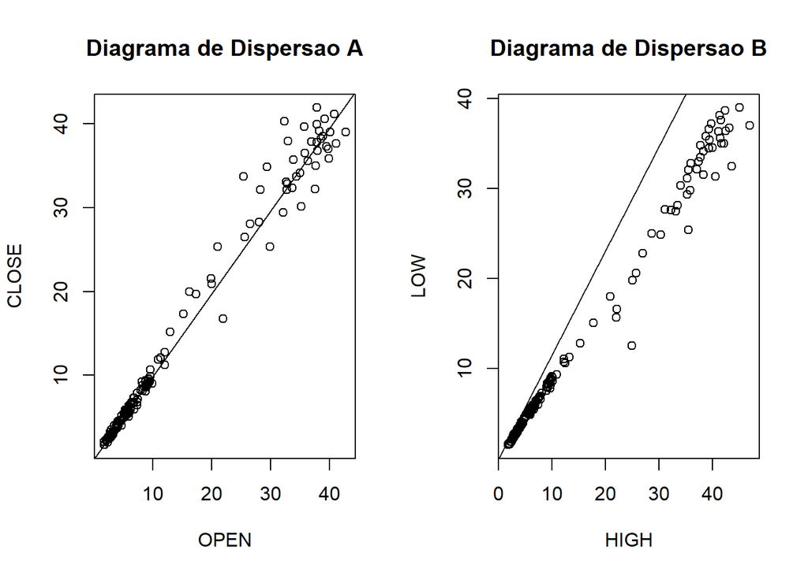

```r
par(mfrow = c(1, 2))
plot(base$Open, base$Close, main = "Diagrama de Dispersao A", xlab = "OPEN", ylab = "CLOSE")
abline(modeloWegeO)

plot(base$High, base$Low, main = "Diagrama de Dispersao B", xlab = "HIGH", ylab = "LOW")
abline(modeloWegeH)
```

## Realizando uma regressão multipla linear

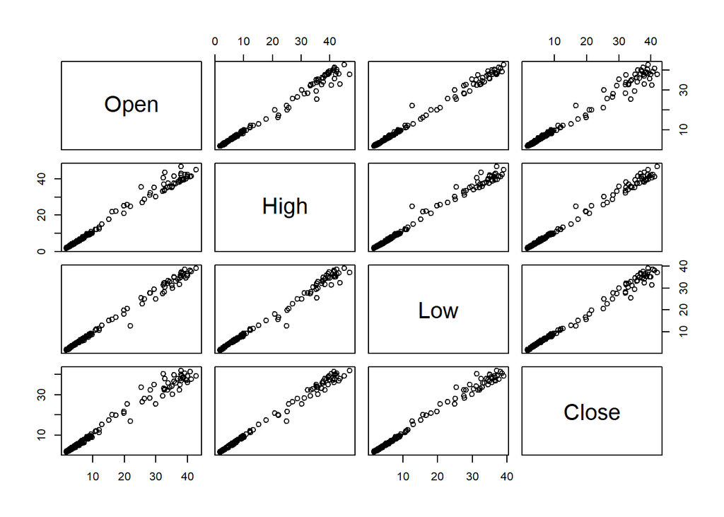

```r
base_completa <- base[,c("Open", "High", "Low", "Close")]

pairs(base_completa)
```

#### Breve Análise:

Agora com a regressão multipla linear é possível observar que os dados tem uma forte correlação positiva entre eles, pois todos formam uma relação linear ou quase linear

```r
library(GGally)
```

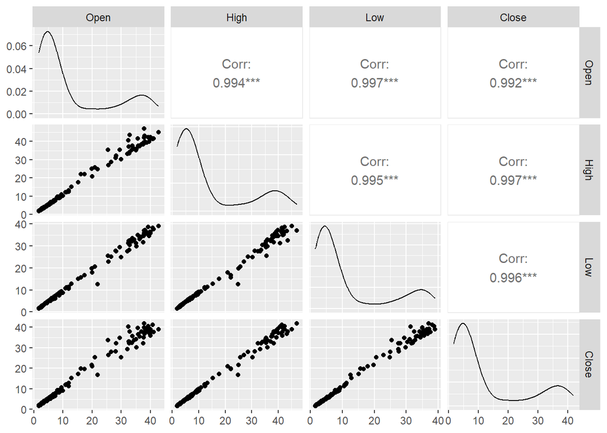

```r
ggpairs(base_completa)
```

```r
summary(base_completa)
```

```
##       Open             High             Low             Close
##  Min.   : 1.701   Min.   : 1.782   Min.   : 1.531   Min.   : 1.723
##  1st Qu.: 3.339   1st Qu.: 3.567   1st Qu.: 3.244   1st Qu.: 3.451
##  Median : 6.158   Median : 6.665   Median : 5.881   Median : 6.169
##  Mean   :12.415   Mean   :13.468   Mean   :11.617   Mean   :12.576
##  3rd Qu.:16.200   3rd Qu.:20.915   3rd Qu.:15.065   3rd Qu.:17.330
##  Max.   :42.705   Max.   :46.930   Max.   :39.005   Max.   :41.895
```

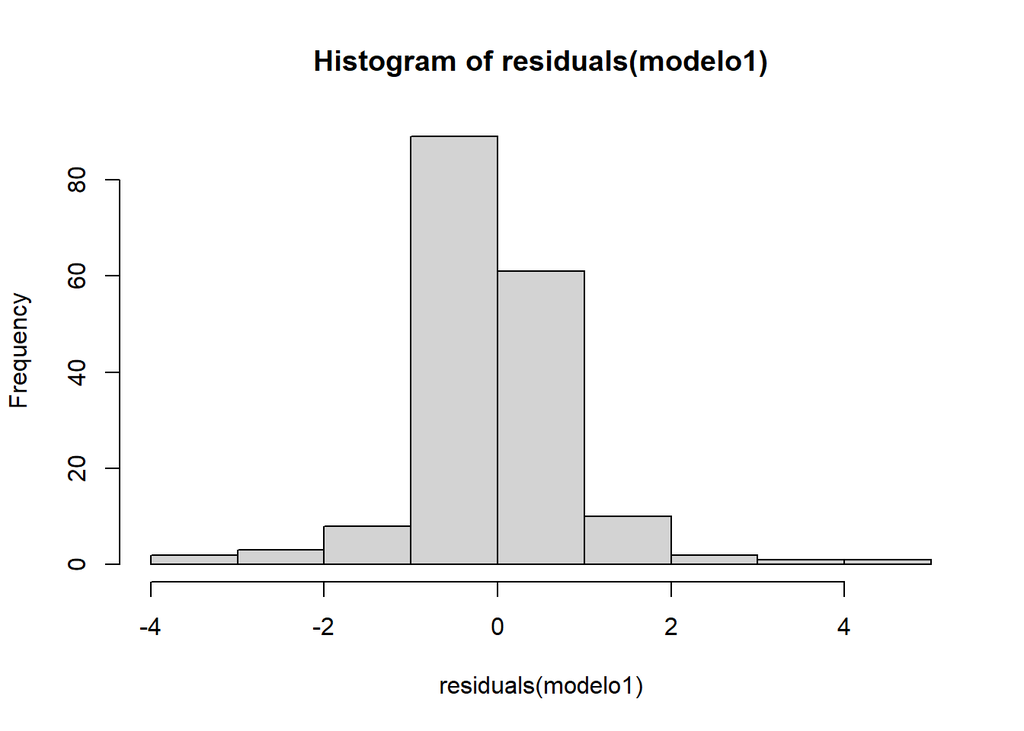

```r
modelo1 <- lm(Open ~ High + Low + Close, data = base_completa)

hist(residuals(modelo1))
```

#### Breve Análise:

É possível ver que há uma distribuição normal desses dados e para confirmar faremos um gráfico de valor ajustado versus resíduo

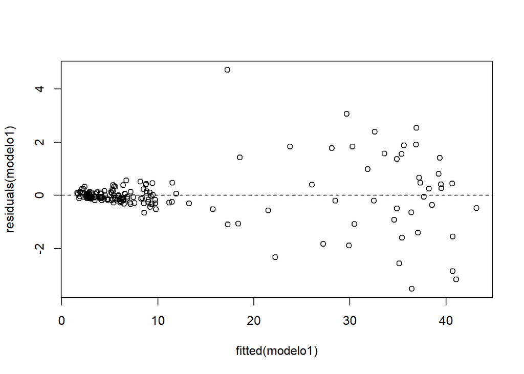

```r
plot(fitted(modelo1), residuals(modelo1))
abline(h = 0, lty = 2)
```

#### Breve Análise:

```r
summary(modelo1)
```

```
##
## Call:
## lm(formula = Open ~ High + Low + Close, data = base_completa)
##
## Residuals:
##     Min      1Q  Median      3Q     Max
## -3.5128 -0.1899 -0.0533  0.1261  4.7093
##
## Coefficients:
##              Estimate Std. Error t value Pr(>|t|)
## (Intercept)  0.004516   0.095583   0.047    0.962
## High         0.524329   0.064438   8.137 7.61e-14 ***
## Low          1.002894   0.066194  15.151  < 2e-16 ***
## Close       -0.501096   0.076380  -6.561 5.98e-10 ***
## ---
## Signif. codes:  0 '***' 0.001 '**' 0.01 '*' 0.05 '.' 0.1 ' ' 1
##
## Residual standard error: 0.9062 on 173 degrees of freedom
## Multiple R-squared:  0.9951, Adjusted R-squared:  0.995
## F-statistic: 1.162e+04 on 3 and 173 DF,  p-value: < 2.2e-16
```

```r
sigma(modelo1)/mean(base_completa$Open)
```

```
## [1] 0.072993
```

#### Breve Análise:

- O summary apresenta que não há uma grande variabilidade desses dados a partir do (>|t|). O modelo se dá útil.
- O Multiple R-squared em 0.9951 siginifica que 99% da variância em Open pode ser explicada pelos preditores do modelo.
- O Residual standard error representa que os valores apresentados caem em média 0.9062 unidades da linha de regressão, ou seja, muito pouco, sendo uma medida de erro de previsõa baixa
- Esse modelo apresenta cerca de 7,29 % de erro de acordo com o sigma

## Conclusão

- A partir dessa base dados, é possível observar que o modelo que mais se adequa é o modelo de regressão linear, a partir da variável de coluna Open dentro da base de dados. De acordo com a divisão feita no início dos diagramas de dispersão, é notável uma forte correlação positiva entre as variáveis chamadas “Open”, “Close” e “High”,“Low” e com os modelos de regressão linear simples foi visto um alto valor no R-Squared o que mostra uma boa capacidade do modelo de explicar a variabilidade dos dados, os summaries, o cook distance e o hist facilitaram a observação de poucos outliers e finalmente é possível confirmar as suposições de que os modelos têm um bom desempenho tanto na explicação quanto na previsão dos dados